# Predicting with trees, Random Forests, & Model Based Predictions

Frank Hettmer

26 September 2017

# Background

Using devices such as Jawbone Up, Nike FuelBand, and Fitbit it is now possible to collect a large amount of data about personal activity relatively inexpensively. These type of devices are part of the quantified self movement - a group of enthusiasts who take measurements about themselves regularly to improve their health, to find patterns in their behavior, or because they are tech geeks. One thing that people regularly do is quantify how much of a particular activity they do, but they rarely quantify how well they do it. We are thanking the involved cooperations for letting us use these data.

# Data

The training data for this project are available here: https://d396qusza40orc.cloudfront.net/predmachlearn/pml-training.csv The test data are available here: https://d396qusza40orc.cloudfront.net/predmachlearn/pml-testing.csv

# Download libraries to be used

```r
library(ElemStatLearn)
library(caret)
library(rpart)
library(randomForest)
library(RCurl)
```

```r
library(Matrix)
library(rpart.plot)
library(RColorBrewer)
library(rattle)
```

# Download Data files

```r
fileUrl<-"https://d396qusza40orc.cloudfront.net/predmachlearn/pml-training.csv"
download.file(fileUrl, destfile = "pmltraining.csv")
training<-read.csv("pmltraining.csv", header=TRUE, na.strings=c("NA",""))

fileUrl<-"https://d396qusza40orc.cloudfront.net/predmachlearn/pml-testing.csv"
download.file(fileUrl, destfile = "pmltesting.csv")
testing<-read.csv("pmltesting.csv", header=TRUE, na.strings=c("NA",""))
```

# Exploring the training set and choosing the columns needed for the analysis.

```r
colnames<-names(training)
colindex<-grep("^accel", colnames)
colclasse<-grep("classe", colnames)
training<-training[,c(40,41,42,63,64,65,116,117,118,154,155,156,160)]
testing<-testing[,c(40,41,42,63,64,65,116,117,118,154,155,156,160)]
sum(is.na(training))
```

```
## [1] 0
```

No empty data fields are used for the analysis. #Setup Training and validation sets. Since the data set is large (about 20.000 rows), 25% is for validation.

```r
set.seed(2014)
inTrain<-createDataPartition(y=training$classe, p=0.75, list = FALSE)
train<-training[inTrain,]
validating<-training[-inTrain,]
```

# Plotting predictors

The predictors are plot before the next steps

```r
summary(training)
```

```
##   accel_belt_x       accel_belt_y     accel_belt_z      accel_arm_x
##  Min.   :-120.000   Min.   :-69.00   Min.   :-275.00   Min.   :-404.00
##  1st Qu.: -21.000   1st Qu.:  3.00   1st Qu.:-162.00   1st Qu.:-242.00
##  Median : -15.000   Median : 35.00   Median :-152.00   Median : -44.00
##  Mean   :  -5.595   Mean   : 30.15   Mean   : -72.59   Mean   : -60.24
##  3rd Qu.:  -5.000   3rd Qu.: 61.00   3rd Qu.:  27.00   3rd Qu.:  84.00
##  Max.   :  85.000   Max.   :164.00   Max.   : 105.00   Max.   : 437.00
##   accel_arm_y      accel_arm_z      accel_dumbbell_x  accel_dumbbell_y
##  Min.   :-318.0   Min.   :-636.00   Min.   :-419.00   Min.   :-189.00
##  1st Qu.: -54.0   1st Qu.:-143.00   1st Qu.: -50.00   1st Qu.:  -8.00
##  Median :  14.0   Median : -47.00   Median :  -8.00   Median :  41.50
##  Mean   :  32.6   Mean   : -71.25   Mean   : -28.62   Mean   :  52.63
##  3rd Qu.: 139.0   3rd Qu.:  23.00   3rd Qu.:  11.00   3rd Qu.: 111.00
##  Max.   : 308.0   Max.   : 292.00   Max.   : 235.00   Max.   : 315.00
##  accel_dumbbell_z  accel_forearm_x   accel_forearm_y  accel_forearm_z
##  Min.   :-334.00   Min.   :-498.00   Min.   :-632.0   Min.   :-446.00
##  1st Qu.:-142.00   1st Qu.:-178.00   1st Qu.:  57.0   1st Qu.:-182.00
##  Median :  -1.00   Median : -57.00   Median : 201.0   Median : -39.00
##  Mean   : -38.32   Mean   : -61.65   Mean   : 163.7   Mean   : -55.29
##  3rd Qu.:  38.00   3rd Qu.:  76.00   3rd Qu.: 312.0   3rd Qu.:  26.00
##  Max.   : 318.00   Max.   : 477.00   Max.   : 923.0   Max.   : 291.00
##  classe
##  A:5580
##  B:3797
##  C:3422
##  D:3216
##  E:3607
##
```

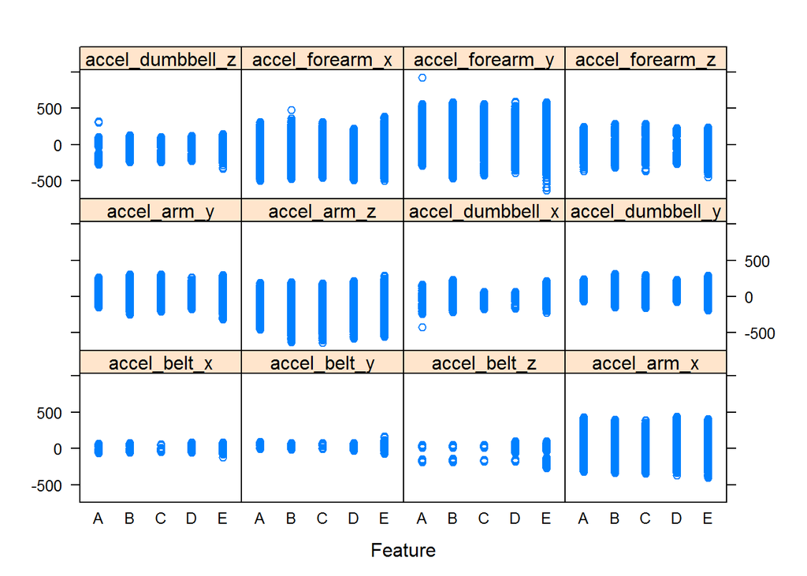

```r
featurePlot(x=training[,c(1:12)], y=training$classe)
```

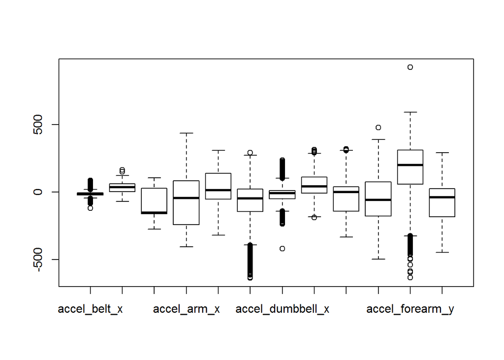

```r
boxplot(training[1:12],training$classe,data=training)
```

```r
corMatrix <- cor(training[1:12])
```